# Индивидуальный проект

Пятый этап

Кузнецова С. В.

Российский университет дружбы народов, Москва, Россия

15 апреля 2023

# Информация

## Докладчик

- Кузнецова София Вадимовна
- студент прикладной информатики
- Российский университет дружбы народов

# Выполнение 5-го этапа индивидуального проекта

## Записи для персональных проектов

Чтобы сделать записи для персональных проектов мы должны проделать данный путь: “work”, “blog”, “content”, “project”, “example”. Внутри каталога “example” мы открываем файл “index.md”.

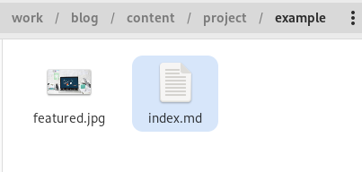

Открытие нужного файла для редактирования

## Редактирование файла

Внутри файла меняем титульное название, а также ссылки на твитер меняем на GitHub. После чего добавляем этапы реализации нашего индивидуального проекта.

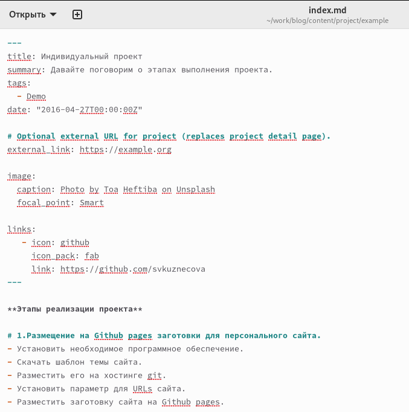

Редактирование файла проекта

## Создание постов

Теперь создадим каталоги для наших новых постов и назовём их: “Моя прошедшая неделя(4)” и “Языки научного программирования”. Чтобы создать эти каталоги нужно проделать следующий путь: “work”, “blog”, “content”, “post”.

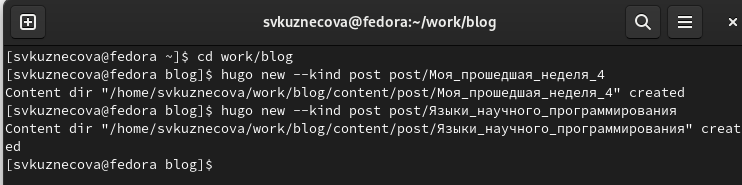

Создание каталогов для новых постов

## Добавление информации для постов

Добавим информацию для наших постов, которую мы написали заранее.

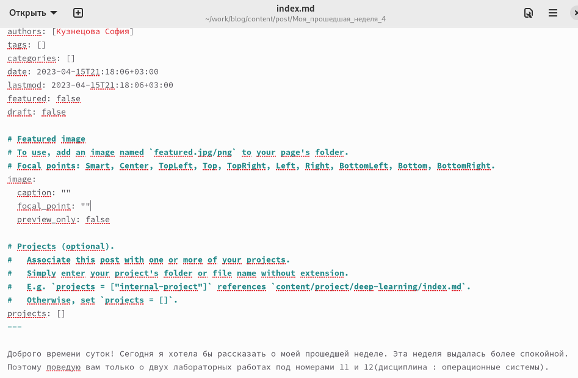

Добавление информации для поста “Моя прошедшая неделя(4)”

## Добавление информации для постов

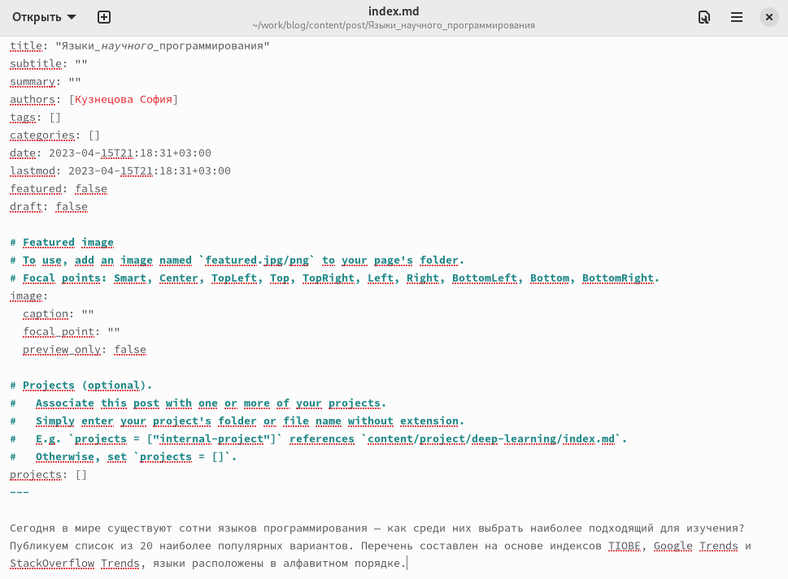

Добавление информации для поста “Языки научного программирования”

## Hugo

Чтобы вся наша информация выгрузилась на сайт, откроем в каталоге “blog” терминал и запустим команду hugo.

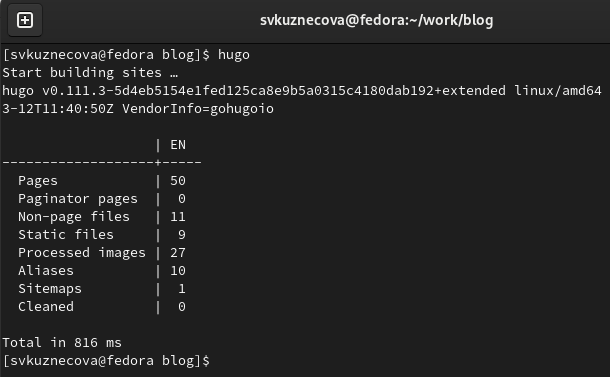

Запуск команды hugo

## Выгрузка из подкаталога “public”

Как только команда hugo выполнилась перейдём первым этапом в подкаталог “public” и проделаем указанные на скриншоте действия. Вторым этапом проделаем все те же самые действия, но уже в каталоге “blog”.

[figure not shown]

Выгрузка из подкаталога “public”

## Выгрузка из каталога “blog”

[figure not shown]

Выгрузка из каталога “blog”

Последним шагом перейдём на еаш сайт и посмотрим итог работы.

## Внешний вид обновлённого сайта

[figure not shown]

Записи для персональных проектов

## Внешний вид обновлённого сайта

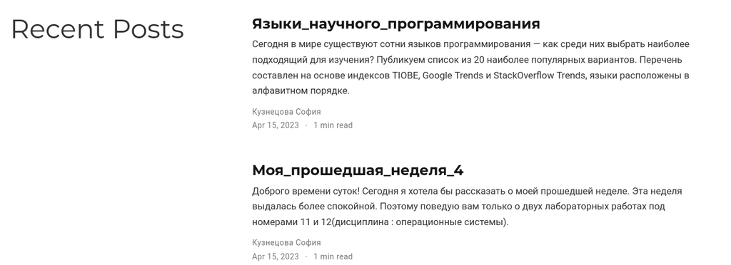

Новые посты

# Вывод

В ходе выполнения пятого этапа индивидуального проекта мы научились добавлять к сайту все остальные элементы.

Спасибо за внимание!